# exam1

Mathias Kold

2024-04-18

## Exam 1 - OLS and heteroskedasticity

Look at the following model for bank employees wage:
$$log(salary)=\beta_0+\beta_1educ+\beta_2log(salbegin)+\beta_3male+\beta_4
minority+u$$
where salary is yearly wage (in 1000 US dollars), educ is education measured in number of years, salbegin is the starting salary (in 1000 US dollars) for the person’s first position in the same bank, male is a dummy variable for gender, minority is one dummy variable indicating whether one belongs to a minority.

## 1 - Estimate the model using OLS. Comment on the output and interpret the results

```r
options(scipen = 999)
library(readr)
library(foreign)
library(car)
data1 <- read_csv("data1.csv")
model <- lm(log(salary) ~ educ + log(salbegin) + male + minority, data = data1)
summary(model)
```

```
##
## Call:
## lm(formula = log(salary) ~ educ + log(salbegin) + male + minority,
##     data = data1)
##
## Residuals:
##      Min       1Q   Median       3Q      Max
## -0.45572 -0.11508 -0.00516  0.10765  0.87060
##
## Coefficients:
##               Estimate Std. Error t value             Pr(>|t|)
## (Intercept)    0.84868    0.07512  11.298 < 0.0000000000000002 ***
## educ           0.02327    0.00387   6.013        0.00000000366 ***
## log(salbegin)  0.82180    0.03603  22.808 < 0.0000000000000002 ***
## male           0.04816    0.01991   2.419               0.0160 *
## minority      -0.04237    0.02034  -2.083               0.0378 *
## ---
## Signif. codes:  0 '***' 0.001 '**' 0.01 '*' 0.05 '.' 0.1 ' ' 1
##
## Residual standard error: 0.1766 on 469 degrees of freedom
## Multiple R-squared:  0.8041, Adjusted R-squared:  0.8024
## F-statistic: 481.3 on 4 and 469 DF,  p-value: < 0.00000000000000022
```

From the estimated model it can be seen that the education variable has a value of 0.02327 which means that one extra year of education will raise the salary by approximately 2.3%. The male variable has a value 0.04816 which means that being a man will raise your salary by approximately 4.8%. The minority variable has a value of -0.04237 which means that minorities approximately will have a 4.2% lower salary than people who are not minorities. The salbegin variable have a different interpretation because it is in log form. It has a value of 0.82180 which means that an increase of 1% in your starting salary will make your salary approximately 0.82% higher.

The intercept is 0.84868 which is the value of the dependent variable, in this case salary, when all other variables have a value of 0. So in this case 0.84868 is the expected value of the salary for a person with zero education, without a starting salary and someone who is not a male or a minority.

It can also be seen that all the variables are statistically significant at a 5% significance level due to p-values < 0.05 but only education and log(salbegin) are statistically significant at a 1% significance level.

## 2 - Perform graphical model checking.

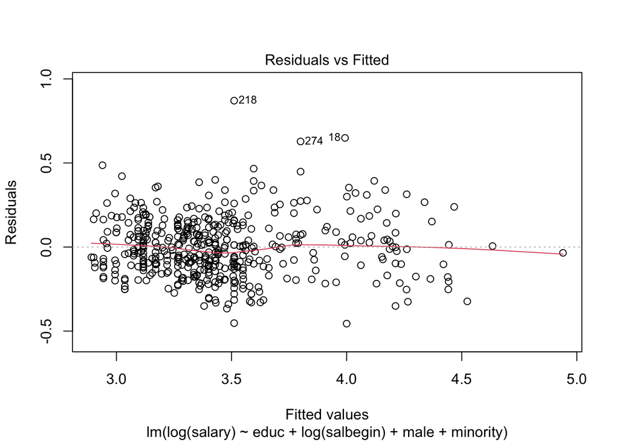

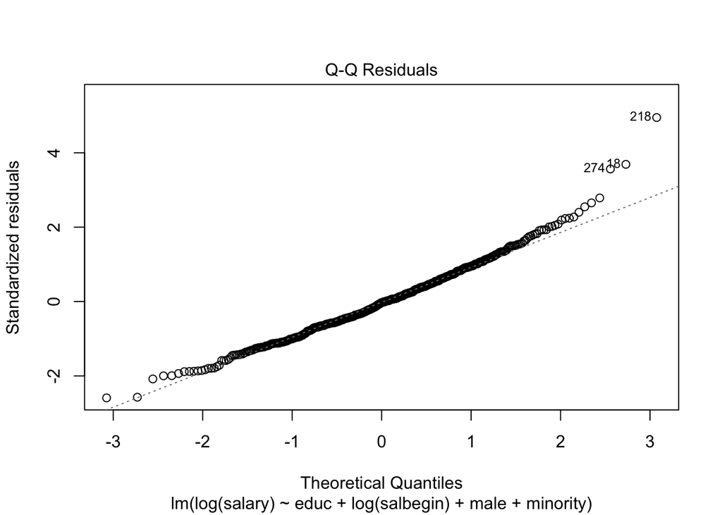

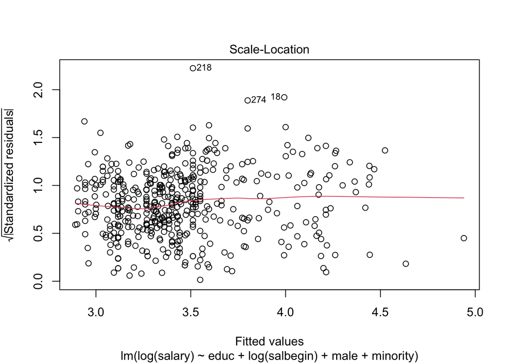

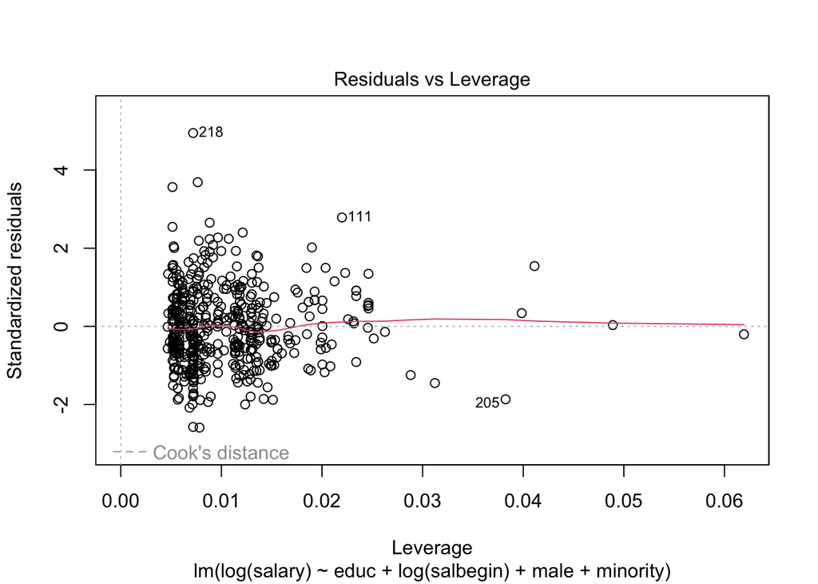

```r
plot(model)
```

The residual vs fitted model shows if the residuals have non-linear patterns. If they are equally spread around a horizontal line without any patterns it indicates that the residuals does not have non-linear patterns. From the plot it can be seen that the spread is quite equal around the horizontal red line, although a few outliers exists, which indicates a linear pattern.

The Q-Q residuals plot shows if the residuals are normally distributed. If the residuals fit the dotted line they are normally distributed. In this case, the residuals fit the dotted line except in the last quantiles where they deviate a bit from the dotted line. This could indicate that the residuals are approximately normally distributed although not perfectly normally distributed.

The scale-location plot shows if homoskedasticity exists within the residuals. If the residuals are spread equally around the predictors, the model fulfills the assumption of homoskedasticity. In this case, it can be argued that there is an increasing pattern in the spread of the residuals which indicates heteroskedasticity.

The residuals vs leverage plot helps detect outliers in the model. It is important because outliers can have a major impact in the model. The residuals can be seen if they have a large Cook’s distance, which is the dashed line. In this case, it seems like there might be an outlier with observation 218 but other than that, most of the observations does not have a large Cook’s distance.